# introduction

#### **Load your single cell object(s)**

AnanseSeurat requires a preprocessed single cell object. Before exporting data make sure the single cell object has been filtered for good quality cells, and has underwent sufficient pre-processing. For guides on pre-processing scRNA-seq and scATAC-seq there are some excelent vignettes and guides available. We will also set the working directory.

```r
# if (!requireNamespace("remotes", quietly = TRUE)) {
#   install.packages("remotes")
# }
# Sys.unsetenv("GITHUB_PAT")
# remotes::install_github("JGASmits/AnanseSeuratWrapper")

library(AnanseSeurat)
library(SeuratDisk)
library(Seurat)
library(Signac)
```

In this example we will use a preprocsed 10x PBMC multiome dataset (PBMC from a Healthy Donor (v1, 150x150) Single Cell Multiome ATAC + Gene Expression Dataset by Cell Ranger ARC 2.0.0). This data was pre-processed following the standard pre-processing from Signac. The pre-pocessed single cell object is available at Zenado: https://zenodo.org/record/7446267/

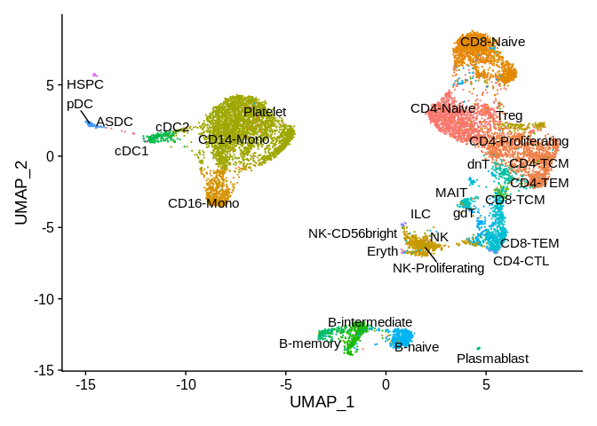

```r
rds_file <- 'preprocessed_PDMC.Rds'
pbmc <- readRDS(rds_file)
DimPlot(pbmc, label = TRUE, repel = TRUE, reduction = "umap") + NoLegend()
```

This single cell object contains multimodal data, both RNA and ATAC signal from each cell. However in the case of a seperate scRNA-seq object and scATAC-seq object, AnanseSeurat can still prepare files for running single cell Ananse. In the case of two seperate objects as input it is important that both the objects share their respective cluster names.

#### **Output files using AnanseSeurat**

We will start with outputting the CPM file, for this we select:

1. the minimum ammount of cells a cluster needs to have to be included via min_cells
2. the output directory
3. the cluster ID containing the cluster names
4. the name of the Assay containing the RNA data.

```r
export_CPM_scANANSE(pbmc,
                    min_cells <- 25,
                    output_dir ='./analysis',
                    cluster_id = 'predicted.id',
                    RNA_count_assay = 'RNA')
```

```
#> [1] "calculating CPM"
#> [1] "gather data from CD4-Naive with 1414 cells"
#> [1] "gather data from CD4-TCM with 1592 cells"
#> [1] "gather data from CD8-Naive with 1496 cells"
#> [1] "gather data from CD16-Mono with 527 cells"
#> [1] "gather data from NK with 492 cells"
#> [1] "gather data from Treg with 160 cells"
#> [1] "gather data from CD14-Mono with 3095 cells"
#> [1] "NK-Proliferating less than 25 skipping"
#> [1] "gather data from CD8-TCM with 73 cells"
#> [1] "gather data from B-intermediate with 351 cells"
#> [1] "gather data from cDC2 with 168 cells"
#> [1] "gather data from B-memory with 159 cells"
#> [1] "Plasmablast less than 25 skipping"
#> [1] "gather data from CD4-TEM with 172 cells"
```

[output cut: 16 more lines]

Next we will output the ATAC peak matrix, , for this we select:

1. the minimum ammount of cells a cluster needs to have to be included via min_cells
2. the output directory
3. the cluster ID containing the cluster names
4. the name of the Assay containing the ATAC peak data.

```r
export_ATAC_scANANSE(pbmc,
                     min_cells <- 25,
                     output_dir ='./analysis',
                     cluster_id = 'predicted.id',
                     ATAC_peak_assay= 'peaks')
```

```
#> [1] "gather data from CD4-Naive with 1414 cells"
#> [1] "gather data from CD4-TCM with 1592 cells"
#> [1] "gather data from CD8-Naive with 1496 cells"
#> [1] "gather data from CD16-Mono with 527 cells"
#> [1] "gather data from NK with 492 cells"
#> [1] "gather data from Treg with 160 cells"
#> [1] "gather data from CD14-Mono with 3095 cells"
#> [1] "NK-Proliferating less than 25 skipping"
#> [1] "gather data from CD8-TCM with 73 cells"
#> [1] "gather data from B-intermediate with 351 cells"
#> [1] "gather data from cDC2 with 168 cells"
#> [1] "gather data from B-memory with 159 cells"
#> [1] "Plasmablast less than 25 skipping"
#> [1] "gather data from CD4-TEM with 172 cells"
#> [1] "gather data from MAIT with 121 cells"
#> [1] "gather data from CD8-TEM with 664 cells"
#> [1] "dnT less than 25 skipping"
#> [1] "gather data from B-naive with 424 cells"
#> [1] "gather data from gdT with 164 cells"
#> [1] "gather data from pDC with 110 cells"
#> [1] "NK-CD56bright less than 25 skipping"
#> [1] "CD4-CTL less than 25 skipping"
#> [1] "ILC less than 25 skipping"
#> [1] "gather data from HSPC with 26 cells"
#> [1] "Eryth less than 25 skipping"
#> [1] "cDC1 less than 25 skipping"
#> [1] "Platelet less than 25 skipping"
#> [1] "CD4-Proliferating less than 25 skipping"
#> [1] "ASDC less than 25 skipping"
```

Next we will generate the config and sample file needed for anansnake, we will also specify specific pairwise comparisons between clusters of interest. By default, scANANSE compares all clusters to a network based on the average values of all clusters. Additional comparisons can be specified, in this case, B-naive and B-memory cells were also specified to compare directly to each other.

```r
#specify additional contrasts:
contrasts <-  list('B-naive_B-memory',
                   'B-memory_B-naive',
                   'B-naive_CD16-Mono',
                   'CD16-Mono_B-naive')

config_scANANSE(pbmc,
                min_cells <- 25,
                output_dir ='./analysis',
                cluster_id = 'predicted.id',
                genome = './data/hg38',
                additional_contrasts = contrasts)
```

```
#> [1] "adding additional contrasts"
#> [1] "anansesnake_CD4-Naive_average"
#> [1] "anansesnake_CD4-TCM_average"
#> [1] "anansesnake_CD8-Naive_average"
#> [1] "anansesnake_CD16-Mono_average"
#> [1] "anansesnake_NK_average"
#> [1] "anansesnake_Treg_average"
#> [1] "anansesnake_CD14-Mono_average"
#> [1] "anansesnake_CD8-TCM_average"
#> [1] "anansesnake_B-intermediate_average"
#> [1] "anansesnake_cDC2_average"
#> [1] "anansesnake_B-memory_average"
#> [1] "anansesnake_CD4-TEM_average"
#> [1] "anansesnake_MAIT_average"
#> [1] "anansesnake_CD8-TEM_average"
#> [1] "anansesnake_B-naive_average"
#> [1] "anansesnake_gdT_average"
#> [1] "anansesnake_pDC_average"
#> [1] "anansesnake_HSPC_average"
#> [1] "anansesnake_B-naive_B-memory"
#> [1] "anansesnake_B-memory_B-naive"
#> [1] "anansesnake_B-naive_CD16-Mono"
#> [1] "anansesnake_CD16-Mono_B-naive"
```

Finally we will calculate the markergenes for each clsuter and between clusters of a specific comparison:

```r
DEGS_scANANSE(pbmc,
              min_cells <- 25,
              output_dir ='./analysis',
              cluster_id = 'predicted.id',
              additional_contrasts = contrasts)
```

#### **run Anansnake on the generated files**

After this all your files are ready to run Anansnake for gene regulatory network analysis. For info on installing and running anansnake see: https://github.com/vanheeringen-lab/anansnake

#### **Import influence scores back into your single cell object**

After running anansnake the results can be incorporated back into your single cell object.

```r
pbmc <- import_seurat_scANANSE(pbmc,
                               cluster_id = 'predicted.id',
                               anansnake_inf_dir= "./analysis/influence/")
```

```
#> [1] "adding cells with no influence scores with NA"
```

The top TFs contributing to your clusters can be vizualized as a table:

```r
TF_influence <- per_cluster_df(pbmc,
  assay = 'influence',
  cluster_id = 'predicted.id')

head(TF_influence)
```

```
#>       CD4-Naive CD4-TCM CD8-Naive CD16-Mono         NK Treg CD14-Mono CD8-TCM
#> EBF1  0.0000000       0 0.0000000 0.0000000 0.00000000    0 0.0000000       0
#> SPIB  0.0000000       0 0.0000000 0.0000000 0.00000000    0 0.0000000       0
#> REL   0.0000000       0 0.0000000 0.9433962 0.09090909    0 0.8181818       0
#> TCF4  0.0000000       0 0.0000000 0.0000000 0.00000000    0 0.0000000       0
#> BACH2 0.8571429       0 0.8823529 0.0000000 0.00000000    0 0.0000000       0
#> PAX5  0.0000000       0 0.0000000 0.0000000 0.00000000    0 0.0000000       0
#>       B-intermediate      cDC2  B-memory CD4-TEM MAIT CD8-TEM   B-naive gdT
#> EBF1          1.0000 0.0000000 1.0000000       0    0       0 1.0000000   0
#> SPIB          0.9375 0.0000000 0.9130435       0    0       0 0.0000000   0
#> REL           0.8750 0.8928571 0.3913043       0    0       0 0.9473684   0
#> TCF4          0.8125 0.3571429 0.6956522       0    0       0 0.7368421   0
#> BACH2         0.7500 0.0000000 0.3913043       0    0       0 0.8947368   0
#> PAX5          0.6875 0.0000000 0.7826087       0    0       0 0.8421053   0
#>             pDC
#> EBF1  0.0000000
#> SPIB  1.0000000
#> REL   0.4827586
#> TCF4  0.9482759
#> BACH2 0.0000000
#> PAX5  0.0000000
```

We can also visualize the influence score of TFs in the single cell object:

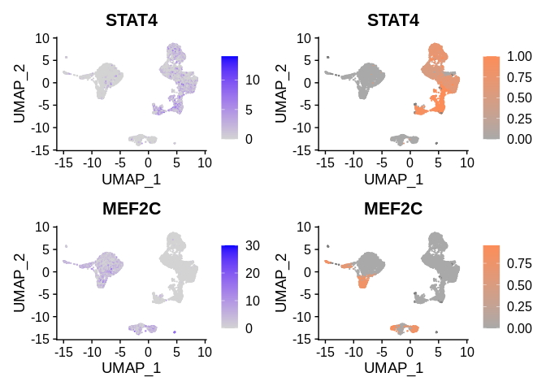

```r
highlight_TF1 <- c('STAT4','MEF2C')

DefaultAssay(object = pbmc) <- "RNA"
plot_expression1 <- FeaturePlot(pbmc, features = highlight_TF1, ncol = 1)
DefaultAssay(object = pbmc) <- "influence"
plot_ANANSE1 <- FeaturePlot(pbmc,ncol = 1, features = highlight_TF1, cols = c("darkgrey", "#fc8d59"))
print(plot_expression1|plot_ANANSE1)
```